# RR Peer Assignment 1

Bedant Das

December 10, 2016

```
## character(0)
```

This assignment makes use of data from a personal activity monitoring device. This device collects data at 5 minute intervals through out the day. The data consists of two months of data from an anonymous individual collected during the months of October and November, 2012 and include the number of steps taken in 5 minute intervals each day.

## 1. Code for reading in the dataset and/or processing the data

```r
get.Activity.url <- "https://d396qusza40orc.cloudfront.net/repdata%2Fdata%2Factivity.zip"
download.file(get.Activity.url,destfile="./activity.zip",method="auto")
unzip(zipfile="./activity.zip",exdir=".")
act1 <- read.csv("activity.csv")
str(act1)
```

```
## 'data.frame':    17568 obs. of  3 variables:
##  $ steps   : int  NA NA NA NA NA NA NA NA NA NA ...
##  $ date    : Factor w/ 61 levels "2012-10-01","2012-10-02",..: 1 1 1 1 1 1 1 1 1 1 ...
##  $ interval: int  0 5 10 15 20 25 30 35 40 45 ...
```

## 2. Histogram of the total number of steps taken each day

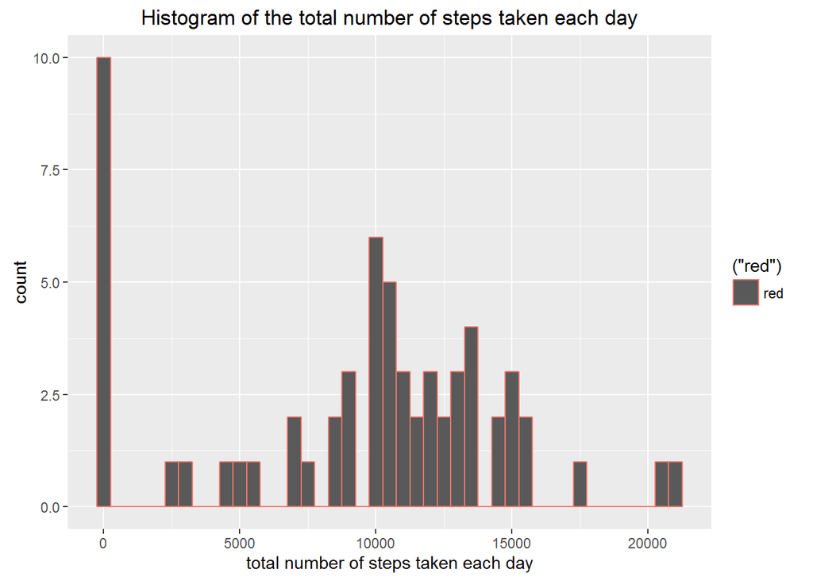

## 3.Mean and median number of steps taken each day

```
## [1] 9354.23
```

```
## [1] 10395
```

## 4. Time series plot of the average number of steps taken in the 5-minute interval that, on average, contains the maximum number of steps

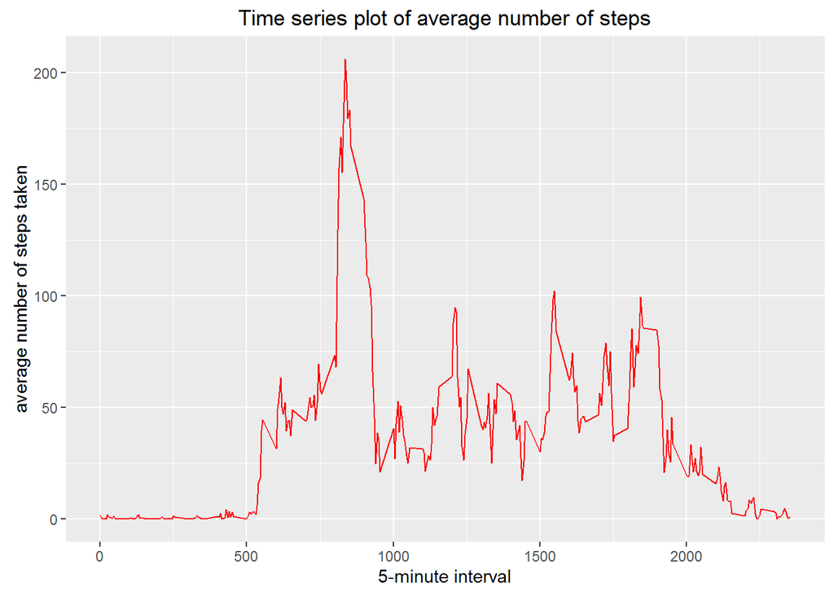

## 5. The 5-minute interval that, on average, contains the maximum number of steps

```r
AvgSteps[which.max(AvgSteps$steps),]
```

```
##     interval    steps
## 104      835 206.1698
```

## 6.Strategy is to replace each missing value with the mean value of its 5-minute interval

```r
missing <- is.na(act1$steps)
table(missing)
```

```
## missing
## FALSE  TRUE
## 15264  2304
```

```r
## Function FillMissingVlaue
FillMissingValue <- function(steps, interval) {
  filled <- NA
  if (!is.na(steps))
    filled <- c(steps)
  else
    filled <- (AvgSteps[AvgSteps$interval==interval, "steps"])
  return(filled)
}
filled.act1 <- act1
filled.act1$steps <- mapply(FillMissingValue, filled.act1$steps,filled.act1$interval)
```

## 7. Histogram of the total number of steps taken each day after missing values are imputed

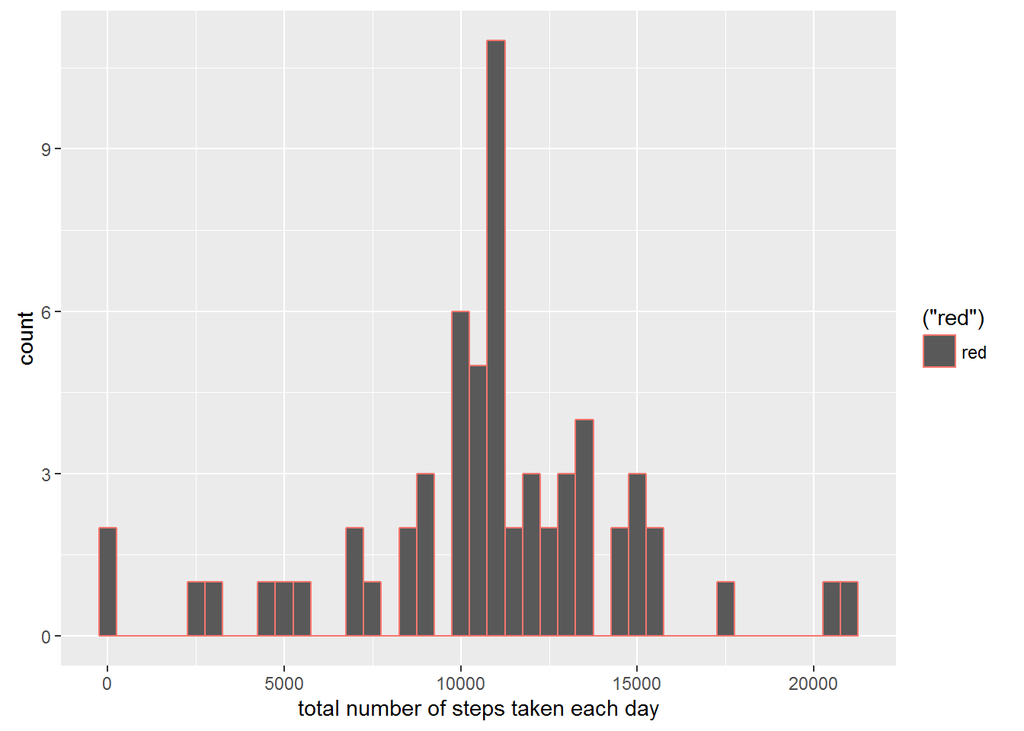

```
## [1] 10766.19
```

```
## [1] 10766.19
```

## 8.Panel plot comparing the average number of steps taken per 5-minute interval across weekdays and weekends

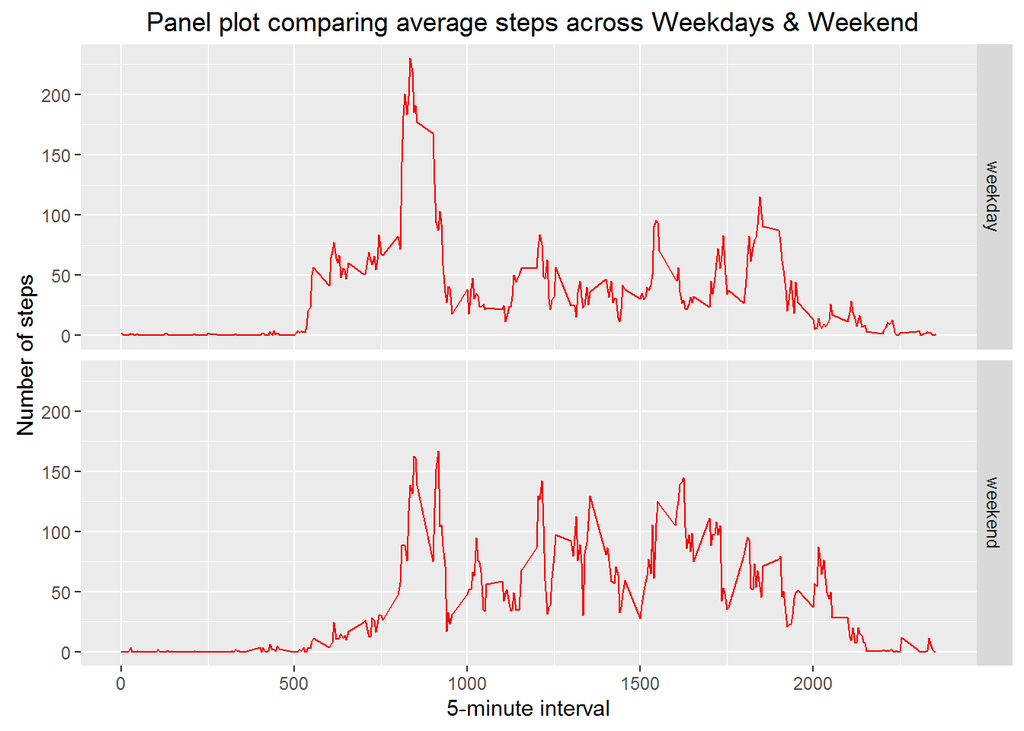